# Busulfan HTML

Claire Seydoux

## Introduction

In this example, we first explore if the BMI is different among two different groups (i.e patients receiving busulfan once a day versus patients receviing busulfan four times a day). We then look the correlation between age and BMI among our population. Finally, we explore the correlation between busulfan clearance and its area-under-the-curve (AUC).

```r
# Read data
library(readxl)
library(here)
bupk <- read_excel(here("data/raw/bupk.xlsx"))
```

## R-script

bu_1 <- subset(bupk,bu_pk1==1) bu_4 <- subset(bupk,bu_pk1==0)

summary(bupk$bmi) summary(bu_1$bmi) summary(bu_4$bmi)

summary(bupk$dx_age) summary(bu_1$dx_age) summary(bu_4$dx_age)

## Figures

1. Figure 1

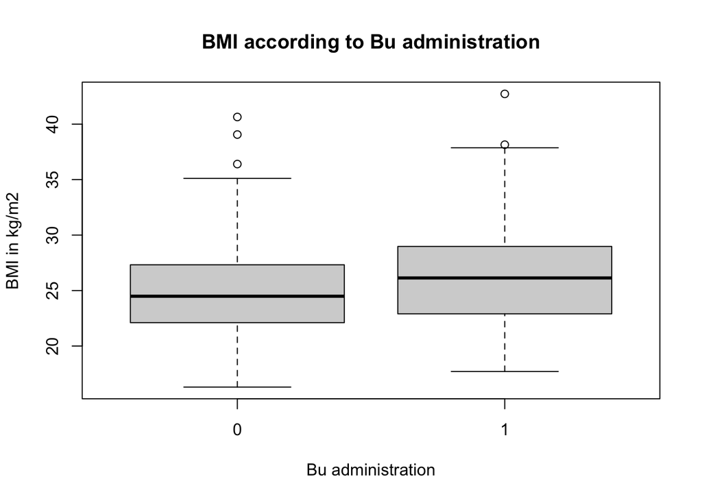

BMI according to Bu administration

```r
p1<- boxplot(bupk$bmi~bupk$bu_pk1, main="BMI according to Bu administration", ylab= "BMI in kg/m2", xlab="Bu administration")
```

2. Figure 2

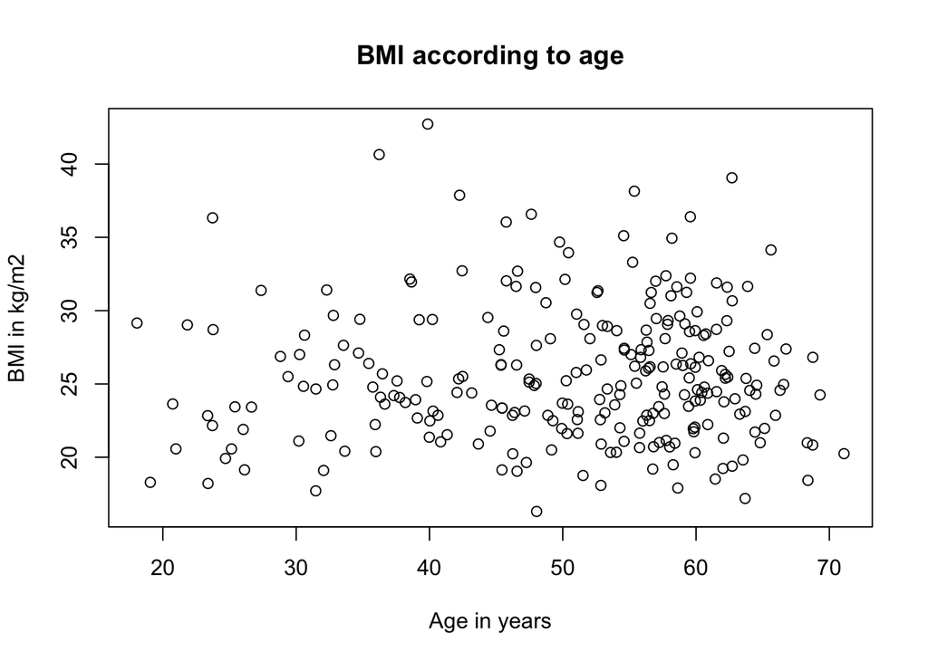

BMI according to age

```r
p2<- plot(bupk$hsct_age, bupk$bmi, main="BMI according to age", ylab= "BMI in kg/m2", xlab="Age in years")
```

3. Figure 3

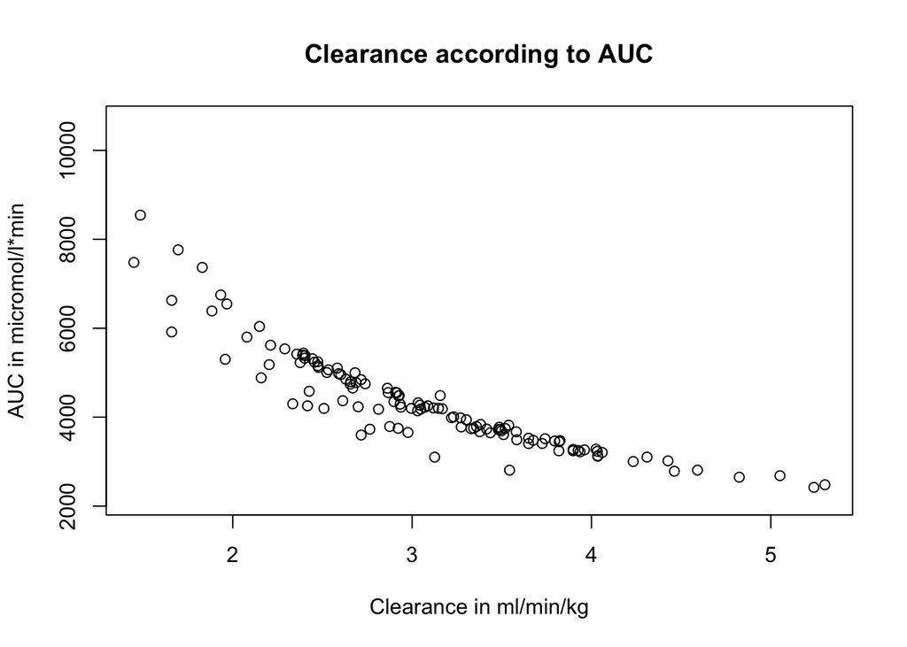

Clearance according to AUC

```r
p3<- plot(bupk$auc~bupk$bu_cl, main="Clearance according to AUC", ylab= "AUC in micromol/l*min", xlab= "Clearance in ml/min/kg")
```

## Conclusion

Here, we see that the patients receiving busulfan once a day are heavier than the ones receiving busulfan four times a day (median BMI of 26.14 versus 24.49). There is no clear association between age and BMI (though correlation analysis has not been done). As expected, we see an important correlation between busulfan clearance and AUC.